# Report: Metagenomic Targeted Sequencing Service

# 1 Results

**Click on the links below to view the results from each analysis:**

**00…AllSamples.Bac16Sv34**  
**1.Healthy.TimepointComparism..Bac16Sv34**  
**2.Obese.CarbTypeEffects..Bac16Sv34**  
**3.Heathy.CarbTypeEffects..Bac16Sv34**  
**4.Obese.Timepointcomparism..Bac16Sv34**

# 2 Controls

The ZymoBIOMICS<sup>®</sup> Targeted Sequencing Service includes both negative and positive quality control samples for every project. Negative controls are included to assess the level of bioburden carried by the wet-lab process. Positive controls utilize a mock microbial community of well-defined composition to ensure that the data generated is representative of the analyzed microbial samples. The barplot below shows the microbial composition of the ZymoBIOMICS<sup>®</sup> Microbial Community Standard (Zymo Research, Irvine, CA) measured in this project. The theoretical composition of the standard can be accessed by clicking on the link below the figure.  
For projects that included DNA purification from raw samples, the ZymoBIOMICS<sup>®</sup> Microbial Community Standard was used as positive control; a blank extraction sample was used as a negative control. For projects that did not include DNA purification (i.e., analysis of DNA samples), the ZymoBIOMICS<sup>®</sup> Microbial Community DNA Standard (Zymo Research, Irvine, CA) was used as positive control; a blank library preparation sample was used as a negative control.

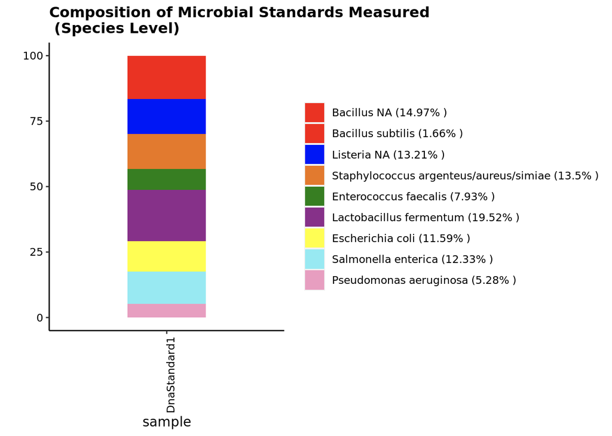

**Theoretical Composition of the ZymoBIOMICS<sup>®</sup> Microbial Community Standard**

[figure not shown]

## 2.1 Absolute Abundance for Controls

The table below shows the absolute abundance data for the ZymoBIOMICS<sup>®</sup> Microbial Community Standards processed, as controls, along with the samples in this project.

**More Information**

**Absolute Abundance Table:**  
1. **sample_id:** unique identification code that was assigned to each sample.  
2. **customer_label:** sample name provided for the project and used in analyses.  
3. **Ct:** cycle at which sample amplified for absolute abundance quantification.  
4. **gene_copies_per_ul:** number of gene copies measured in one microliter of DNA sample.  
5. **genome_copies_per_ul*:*** number of genome copies in one microliter of DNA sample calculated using an assumed number of four (4) 16S copies per genome or two hundred (200) ITS copies per genome.  
6. **DNA_ng_per_ul:** amount of DNA in one microliter of DNA sample calculated using genome_copies and an assumed genome size of 4.64 x 106 bp (Escherichia coli) for 16S or 1.20 x 107 bp (Saccharomyces cerevisiae) for ITS.

*Genome copies per microliter and DNA ng per microliter are calculated from the gene copies per microliter measured in the sample. See the Materials & Methods section for more information.

| sample_id | customer_label | Ct | gene_copies_per_ul | genome_copies_per_ul* | DNA_ng_per_ul* |
| --- | --- | --- | --- | --- | --- |
| Plate1P_V3V4 | DnaStandard1 | 13.89 | 115314622 | 28828656 | 146.6039125 |
| Plate1N_V3V4 | LibNegative1 | 40.25 | 2 | 1 | 0.0000051 |

# 3 Raw Data

**Click on the link below to download the raw FASTQ files for the samples in this project:**

**https://zymo-microbiomics-service.s3.amazonaws.com/epiquest/epiquest_zr24558/GEPLETHTXGCRXQTC/rawdata/zr24558.rawdata.250813.zip**

# 4 Materials and Methods

The samples were processed and analyzed with the ZymoBIOMICS<sup>®</sup> Targeted Sequencing Service (Zymo Research, Irvine, CA).

**DNA Extraction:** One of two different DNA extraction kits was used depending on the sample type and sample volume. In most cases, the ZymoBIOMICS<sup>®</sup>-96 MagBead DNA Kit (Zymo Research, Irvine, CA) was used to extract DNA using an automated platform. In some cases, ZymoBIOMICS<sup>®</sup> DNA Miniprep Kit (Zymo Research, Irvine, CA) was used for low biomass samples such as skin swabs, as it permits for a lower elution volume, resulting in more concentrated DNA samples.

**Targeted Library Preparation:** Bacterial 16S ribosomal RNA gene targeted sequencing was performed using the *Quick*-16S<sup>™</sup> NGS Library Prep Kit (Zymo Research, Irvine, CA). In most cases, the bacterial 16S primers amplified the V3-V4 region of the 16S rRNA gene. These primers have been custom-designed by Zymo Research to provide the best coverage of the 16S gene while maintaining high sensitivity. Fungal ITS gene targeted sequencing was performed using the *Quick*-16S<sup>™</sup> NGS Library Prep Kit with custom ITS2 primers substituted for 16S primers.

The sequencing library was prepared using an innovative library preparation process in which PCR reactions were performed in real-time PCR machines to control cycles and therefore limit PCR chimera formation. The final PCR products were quantified with qPCR fluorescence readings and pooled together based on equal molarity. The final pooled library was cleaned with the Select-a-Size DNA Clean & Concentrator<sup>™</sup> (Zymo Research, Irvine, CA), then quantified with TapeStation<sup>®</sup>(Agilent Technologies, Santa Clara, CA) and Qubit<sup>®</sup> (Thermo Fisher Scientific, Waltham, WA).

**Control Samples:** The ZymoBIOMICS<sup>®</sup> Microbial Community Standard (Zymo Research, Irvine, CA) was used as a positive control for each DNA extraction, if performed. The ZymoBIOMICS<sup>®</sup> Microbial Community DNA Standard (Zymo Research, Irvine, CA) was used as a positive control for each targeted library preparation. Negative controls (i.e. blank extraction control, blank library preparation control) were included to assess the level of bioburden carried by the wet-lab process.

**Sequencing:** The final library was sequenced on Illumina<sup>®</sup> Nextseq<sup>™</sup> with a P1 reagent kit (600 cycles). The sequencing was performed with 30% PhiX spike-in.

**Bioinformatics Analysis:** Unique amplicon sequences variants were inferred from raw reads using the DADA2 pipeline (Callahan et al, 2016). Potential sequencing errors and chimeric sequences were also removed with the Dada2 pipeline. Taxonomy assignment was performed using Uclust from Qiime v.1.9.1 with the Zymo Research Database, a 16S database that is internally designed and curated, as reference. Composition visualization, alpha-diversity, and beta-diversity analyses were performed with Qiime v.1.9.1 (Caporaso et al., 2010). If applicable, taxonomy that have significant abundance among different groups were identified by LEfSe (Segata et al., 2011) using default settings. Other analyses such as heatmaps, Taxa2ASV Deomposer, and PCoA plots were performed with internal scripts.

**Absolute Abundance Quantification*:** If performed, a quantitative real-time PCR was set up with a standard curve. The standard curve was made with plasmid DNA containing one copy of the 16S gene and one copy of the fungal ITS2 region prepared in 10-fold serial dilutions. The primers used were the same as those used in Targeted Library Preparation. The equation generated by the plasmid DNA standard curve was used to calculate the number of gene copies in the reaction for each sample. The PCR input volume was used to calculate the number of gene copies per microliter in each DNA sample. The resulting values are shown in the gene_copies column of the absolute abundance results table.

The number of genome copies per microliter DNA sample (genome_copies) was calculated by dividing the gene copy number by an assumed number of gene copies per genome. The value used for 16S copies per genome is 4. The value used for ITS copies per genome is 200. The amount of DNA per microliter DNA sample (DNA_ng) was calculated using an assumed genome size of 4.64 x 10<sup>6</sup> bp, the genome size of *Escherichia coli*, for 16S samples, or an assumed genome size of 1.20 x 10<sup>7</sup> bp, the genome size of *Saccharomyces cerevisiae*, for ITS samples. This calculation is shown below:

*Calculated Total DNA = Calculated Total Genome Copies × Assumed Genome Size (4.64 × 10<sup>6</sup> bp) × Average Molecular Weight of a DNA bp (660 g/mole/bp) ÷ Avogadros Number (6.022 x 10<sup>23</sup>/mole)*

*Please note that absolute abundance quantification is performed only for 16S and ITS projects.

# 5 References

Callahan B.J., McMurdie P.J., Rosen M.J., Han A.W., Johnson A.J., Holmes S.P., (2016) DADA2: High resolution sample inference from Illumina amplicon data. Nat Methods 13(7):581-3.

Caporaso, J.G., Kuczynski, J., Stombaugh, J., Bittinger, K., Bushman, F.D., Costello, E.K. et al. (2010) QIIME allows analysis of high-throughput community sequencing data. Nat Methods 7: 335-336.

Segata, N., Izard, J., Waldron, L., Gevers, D., Miropolsky, L., Garrett, W.S., and Huttenhower, C. (2011) Metagenomic biomarker discovery and explanation. Genome Biol 12: R60.

[figure not shown]

[figure not shown]

[figure not shown]